# Ch. 8 and 9 HW due 2.6.22 Soc 723

Brenda Onyango

1/29/2022

## Chapter 8: Causal Paths

1. An open path is one that has variation in all the variables along the path. A closed path is one in which at least one variable has no variation.
1. List every path from X -> Y:
1. X -> A -> Y
2. X <- B -> Y
3. X -> C <- D -> Y
4. X <- B <- D -> Y
5. X -> C <- D -> B -> Y
2. front door paths:

X -> A -> Y is the front door path since it’s the only path where all the arrows point away from X. I decided X -> C <- D -> Y is NOT a front door path since D points toward X and C is a collider.

3. which are open back-door paths (arrows toward X and no colliders):
1. X <- B -> Y
2. X <- B <- D -> Y
4. what *must* be controlled to find effect of X on Y:

Ch. says we can pick one variable along each bad path to control for to find answer to research question. The paths without colliders are 2 and 4 from part a.

I need to control for B and D to find the effect of X on Y.

### Income and Health

1. loading package needed to draw causal diagram.

```r
library(ggdag)
```

```r
library(ggplot2)
```

The experience or absence of racism and sexism affects income across strata. Income leads to access to built environments (green space and sidewalks on one extreme and no sidewalks and no green space at the other extreme) and affects if people have housing at all and if they do have housing whether it is free of toxicants (mold, pests, etc.) or not. In the U.S. for many people, their job determines their health insurance status which affects if and which health facilities they can receive care. The predictor variable/treatment is income and the outcome variable is health. The six added variables are racism, sexism, job, insurance, built environment, and housing.

The diagram of these variables are below.

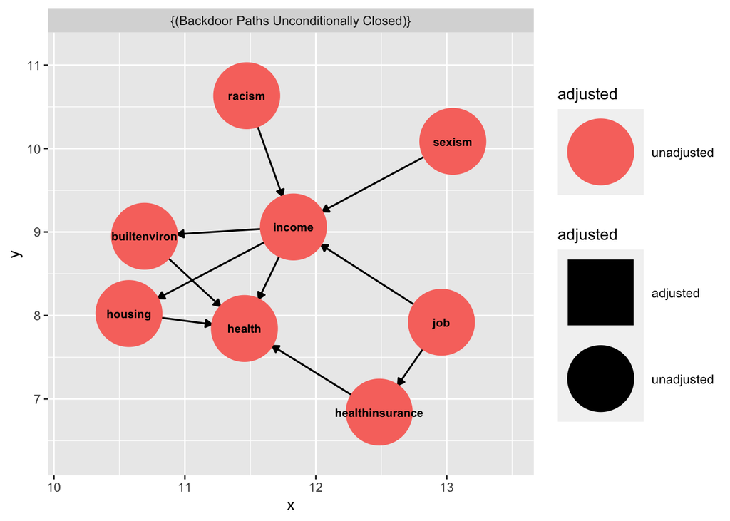

```r
incomedag <- dagitty::dagitty("dag {

  health <- builtenviron
  builtenviron <- income
  housing <- income
  health <- housing
  income <- job
  healthinsurance <- job
  health <- healthinsurance
  health <- income
  income <- racism
  income <- sexism
  job [exposure]
  health [outcome]
}")

tidy_dagA <- tidy_dagitty(incomedag)

ggdag_adjustment_set(incomedag, node_size = 21, text_size = 2.8, text_col = 'black')
```

2. front door paths (all arrows pointing away from income and leading to health):
1. income -> builtenvironment -> health
2. income -> housing -> health
3. income -> health

Based on chapter 6 and 7 I could combine builtenvironment and housing into one variable called neighborhood, but I think there’s a meaningful difference between household toxic exposures or having housing and the access to areas for physical/mental wellness like parks.

3. back door paths (arrows pointing to income):
1. income <- job -> healthinsurance -> health
4. direct effects:

income -> health

Though I don’t think this is realistic as the relationship between income and health might change based on economic structure (democratic socialism v. market-based healthcare).

5. Good Paths:
1. income -> builtenvironment -> health
2. income -> housing -> health
3. income -> health

Bad Paths:

income <- job -> healthinsurance -> health

### Arrows point away from treatment

4. 3. Front door path (path where all arrows point away from treatment)

### Teaching Quality & Popularity

1. In one path of this diagram, popularity is an outcome variable. We could ask “what is the relationship between teaching quality (treatment) and popularity (outcome)?”
2. If we controlled for popularity, which is a collider between teaching quality and numberofpublications, then the path between teachingquality and numberofpublications opens. Opening this path allows us to ask/answer “what effect does teachingquality have on numberofpublications?” or vice versa depending which of the two other variables we want to view as a treatment.

### Lockdown and Recession

1. paths from lockdown to recession, but for those through stimulus:
1. lockdown -> recession
2. lockdown -> unemployment -> recession
3. lockdown <- prior economy -> recession
4. lockdown <- prior economy -> unemployment -> recession

paths with stimulus are: 1. lockdown <- prior economy -> stimulus -> recession 2. lockdown <- prior economy -> stimulus -> unemployment -> recession

2. front door paths:
1. lockdown -> recession
2. lockdown -> unemployment -> recession
3. If we controlled for unemployment we could answer the question “other than through unemployment, does lockdown cause recession?” I.e. if we controlled for unemployment then we would only study direct effects.
4. It depends on what we mean by adequate. Most of the variables have measurement issues. For example, the sporadic closing of some businesses in some states is what some might view as a lockdown, but compared to countries that limited movement, provided meals, and had a serious test, trace, and isolate program, the U.S. did not have a lockdown.There’s also a question of duration of lockdown and whether non-pharmaceutical interventions (e.g., masks) should be considered as part of the lockdown definition.

Secondly, prioreconomy is nebulous - does the author mean since the last recession or since the 1980s and does their measures of economy limit them to stock performance or are they interested in inflation, growth in houselessness, measures of wage, or other metrics of the real economy versus the speculative economy.

Government unemployment numbers are also misleading. https://www.marketwatch.com/story/why-the-unemployment-rate-is-so-misleading-2013-03-08

Recession is based on GDP so that is probably the variable that can be measured the most adequately even with the issues with GDP. Stimulus can also be measured adequately. The other variables will have much debate.

5. An improved path would include pandemic pathogen -> morbidity/mortality -> fewer employees -> recession and other paths that highlight that allowing a virus to spread can’t lead to economic prosperity.

### Bad Paths

1. higher education <- familywealth -> income
2. higher education <- student loan policy <- president -> wage/tax policy -> income

## Chapter 9: Finding Front Doors

1. 2. natural experiment is when randomization of treatment occurs *without* a researcher controlling the randomizaton.

### Necessary Conditions

2. 1. The variation we need to isolate when we’re trying to isolate front door paths must have no open back doors (be closed) and contain the treatment. This is known as exogenous variation.
2. Experiments ensure that variation in the treatment contain no back doors by randomizing which parts of the sample get treatment and which don’t.

### Randomized Experiments v. Natural Experiments

3. 4 major differences between randomized experiments & natural experiments:
1. Natural experiments will sometimes have back doors between the source of exogenous variation and the outcome. Randomized trials will not have back doors.
2. Natural experiments won’t have social desirability bias. Randomized trials require consent and the knowledge of being in a study may affect behavior.
3. Natural experiments toss out any treatment that occurs for other reasons besides natural randomness and the treatment effect observed is only among the group of people who experienced the natural randomness. This means we won’t know the effect of treatment on outcome for those not subject to the natural randomness. With RCTs, we can plan ahead and select different samples and then randomize to treatment and control to understand treatment effects across different groups (e.g., we can do an RCT of a language learning app in multiple countries with people randomized to treatment and control to see if the effect of the app on language acquisition varies across groups).
4. RCTs enjoy high faith that their source of variation in treatment does not have open back doors. Natural experiments produce doubt about whether the source of variation is truly exogenous.
5. Bonus: Natural experiments will have bigger samples sizes made up of more than people who are prone to volunteering. There are restrictions (e.g., pregnant women in drug trials) and potential biases (affinity for volunteering) that lead to a potential skew in the sample size and diversity for a randomized trial.

### Causal & Unfeasible Research Question

4. Last semester we discussed the ethics of a model (is it fair, how will the data be used, biases, and how will data impact individuals and society) and those ethical questions can affect the feasibility of a study. An experimental question that is unfeasible is “what effect does a woman’s botox regimen have on annual performance reviews?” It would be unethical to randomize women to receive botox or not and it would be challenging to isolate whether botox regimen alone affects results of a performance review.
5. Exogenous variation is variation in treatment that has no back doors meaning that variation to treatment or not is not caused by some factor that also causes the outcome.

### A Natural Experient

6. 1. A natural experiment is states adopting different tax rates for cigarettes. This would allow us to see if there is a threshold of cigarette price that affects how many people smoke or at least how many cigarettes people buy.I think I want to analyze how many cigarettes people buy (individual smoking behavior change versus looking at number of smokers). Variables: parent smoking status, peer smoking status, cancer burden in a state, state’s cigarette tax, cigarette price, nicotine addiction, cigarette purchase

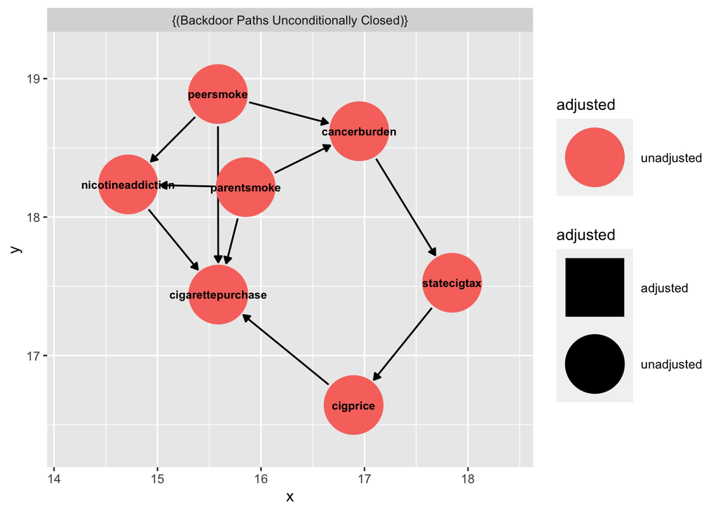

```r
cigdag <- dagitty::dagitty("dag {

  cigarettepurchase <- peersmoke
  cigarettepurchase <- parentsmoke
  cigarettepurchase <- nicotineaddiction
  nicotineaddiction <- peersmoke
  nicotineaddiction <- parentsmoke
  cigprice <- statecigtax
  statecigtax <- cancerburden <- parentsmoke
  statecigtax <- cancerburden <- peersmoke
  cigarettepurchase <- cigprice

  parentsmoke [exposure]
  cigarettepurchase [outcome]
}")

tidy_dagB <- tidy_dagitty(cigdag) #expsure of interst is cigarette tax but needed to write parentsmoke for dag to work

ggdag_adjustment_set(cigdag, node_size = 19, text_size = 2.8, text_col = 'black')
```

2. paths from exogenous variation to outcome:
1. state cigarette tax -> cigarette price -> cigarettepurchase
2. state cigarette tax <-cancerburden <- peersmoke -> cigarettepurchase
3. state cigarette tax <-cancerburden <- peersmoke -> nicotine addiction -> cigarettepurchase
4. state cigarette tax <- cancerburden <- parentsmoke -> cigarettepurchase
5. state cigarette tax <- cancerburden <- parentsmoke -> niicotine addiction -> cigarettepurchase
3. The paths that need to be closed are numbers 2 through 5 in part b.
4. Since there are other reasons people choose to smoke and other factors that determine a state’s tax rate for cigarettes, it is not believable that I haven’t missed any paths. I do think I can close the paths I need for this question, not only because other researchers have estimated the effect of tax rate on cigarettes (precedence), but also because of the ability to compare smoking rates before and after a state had a cigarette tax and trends in cigarette purchases as the tax rate changes. Essentially, the treatment group can also be it’s comparison which could allow me to hold all other factors I didn’t control for or perceive constant.
7. b; looking at charter school example the reason we can use LotteryWin to predict student achievement is because it doesn’t have a backdoor path to student achievement.

### Natural Experiment: Exports and Public Opinion

8. 1. A potential backdoor is bilateral relationships between Brazil and China or other countries that the U.S. is antagonistic to. Industries that may be in jeopardy of damaging relations with China because of taking their market share with the U.S. may not improve their opinion of the U.S. Another backdoor is other trade agreements and regulations for imports to the U.S.; if manufacturers have to adjust their product to meet U.S. market regulations then Brazilian industry opinion of the U.S. may remain the same or worsen (I’m thinking of the issues with sanitation regulation of Brazil exporting meat to the U.S.).
2. I would not believe the results. I would think the study design is good if they truly were able to identify industries affected by the tariffs on an external country, and somehow measure their affect toward the U.S. would answer the question do tariffs change the opinion of the U.S. However, I would not base my acceptance or rejection of the results on one study and I would want to see alternate methods of isolating the assignment to treatment (exports increase because of tariffs) or no treatment (exports not directly affected by tariffs). Supply chains are complex and interrelated so I would have doubts that the analysis was truly able to say which industries exports were affected by U.S. tariffs on other countries and these weren’t.